# Attud - Brief Report

Henrique Pinto Gomide

26-11-2014

# 1 Introduction

This is the first report about the survey “International Needs for Treating Tobacco Use”. The survey has as the main objective understand the needs of tobacco treatment provider.

Be advised, this is the just the first report. It might contain errors.

# 2 Method

All technology (until this date) are freely available on internet. This report was generated using R.

# 3 Practioner Role and Trainning

## 3.1 How did you learn how to treat tobacco dependence?

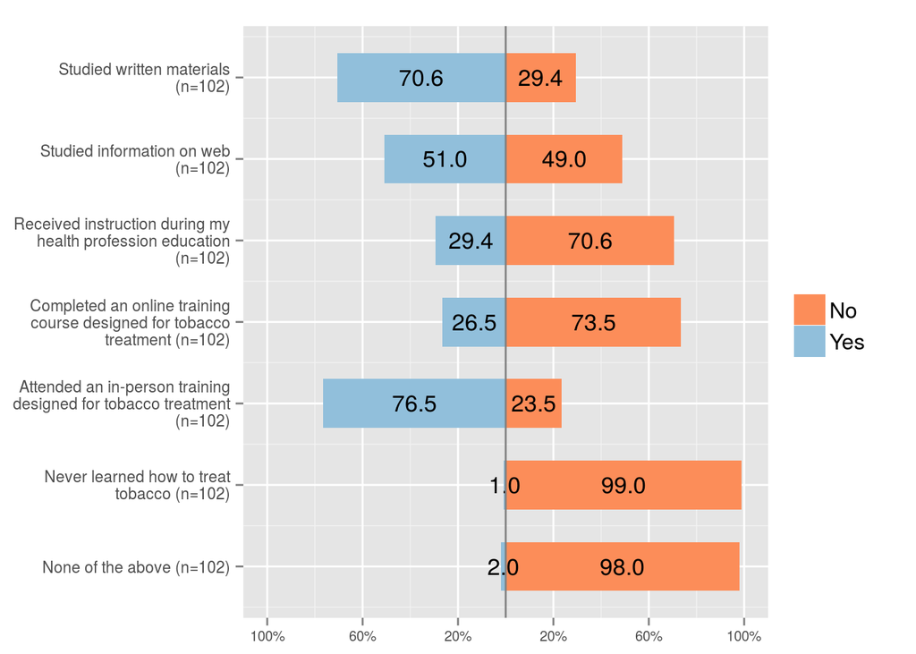

## 3.2 What tobacco treatment activities do you currently perform?

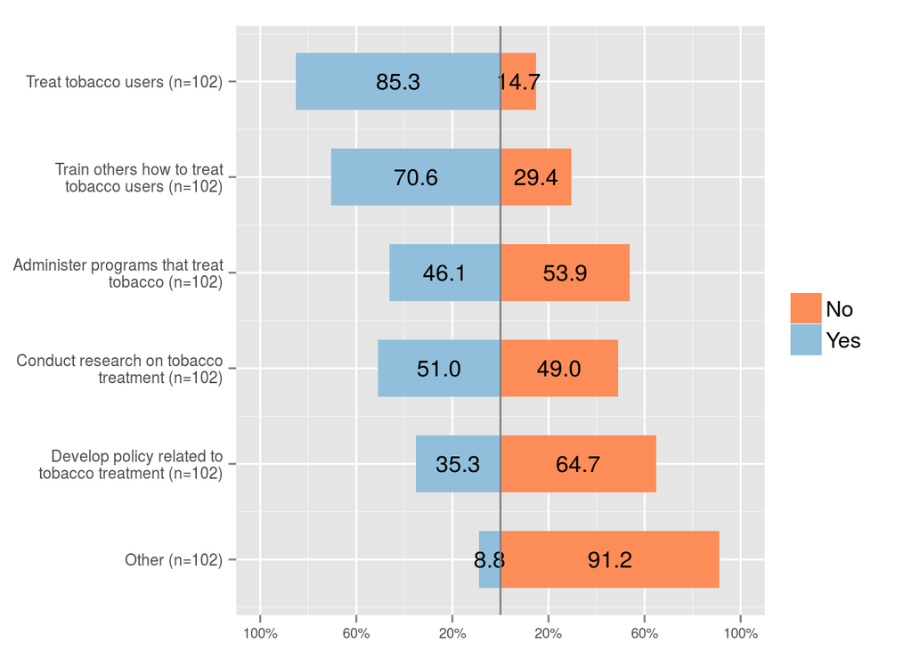

# 4 Tobacco Treatment Training in Your Country

## 4.1 Think back to your professional training curriculum. About how many hours of instruction in how to treat tobacco dependence were provided?

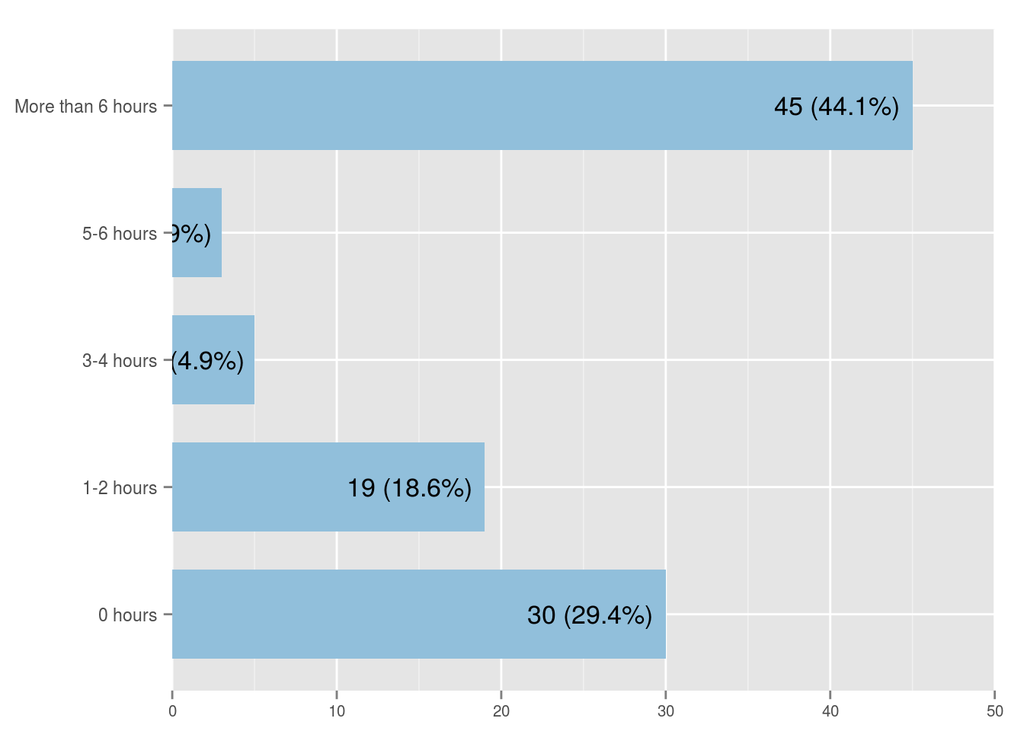

## 4.2 Outside of health care provider education, is any form of training for treating tobacco dependence available in your country?

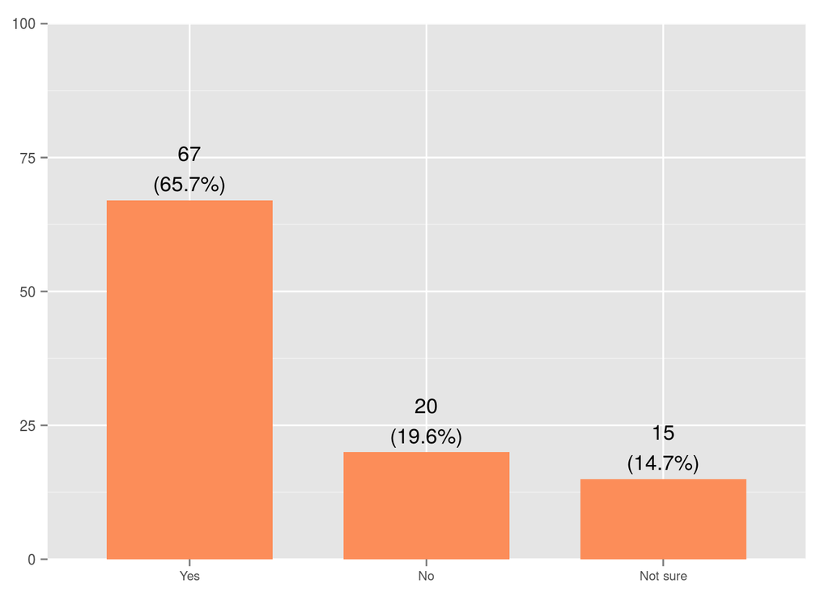

## 4.3 Overall, how would you rate access to tobacco treatment training in your country?

[figure not shown]

## 4.4 Overall, how would you rate the quality of the tobacco treatment training that is available in your country?

[figure not shown]

## 4.5 Does your country have any form of professional certification for tobacco treatment?

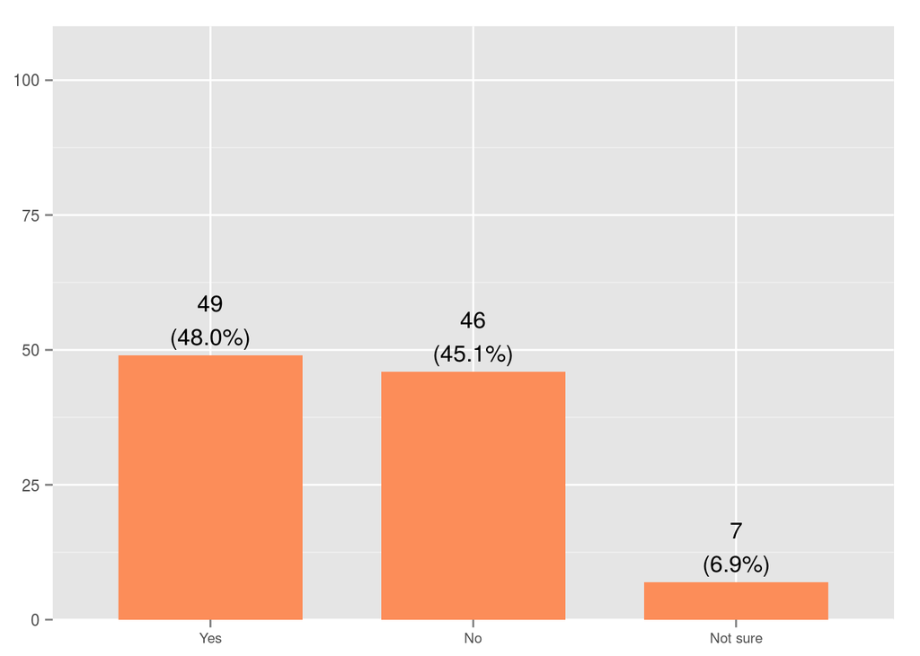

# 5 Guidelines for Tobacco Treatment

## 5.1 Does your country have national guidelines for the treatment of tobacco dependence?

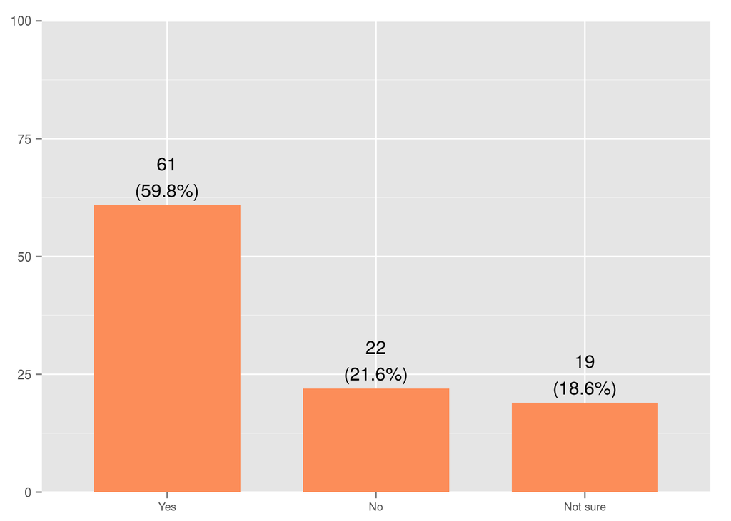

# 6 Demografics

## 6.1 Age

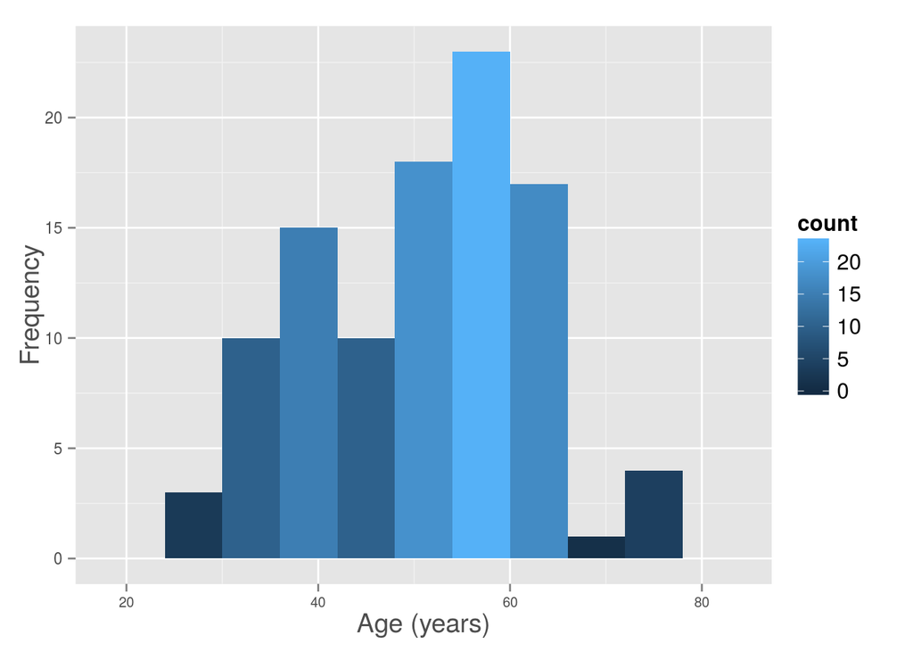

## 6.2 Sex

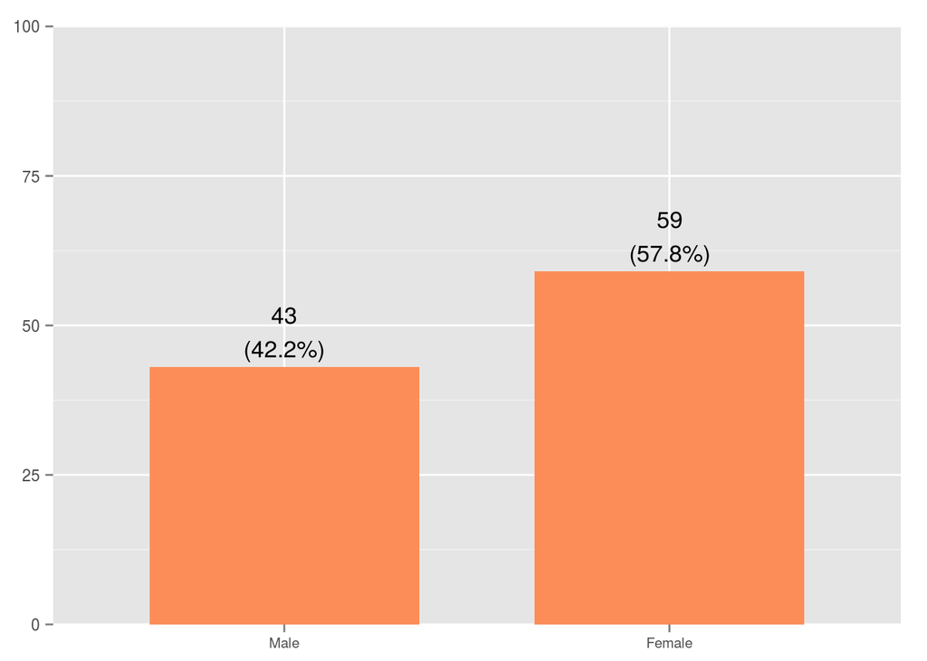

## 6.3 What is your profession?

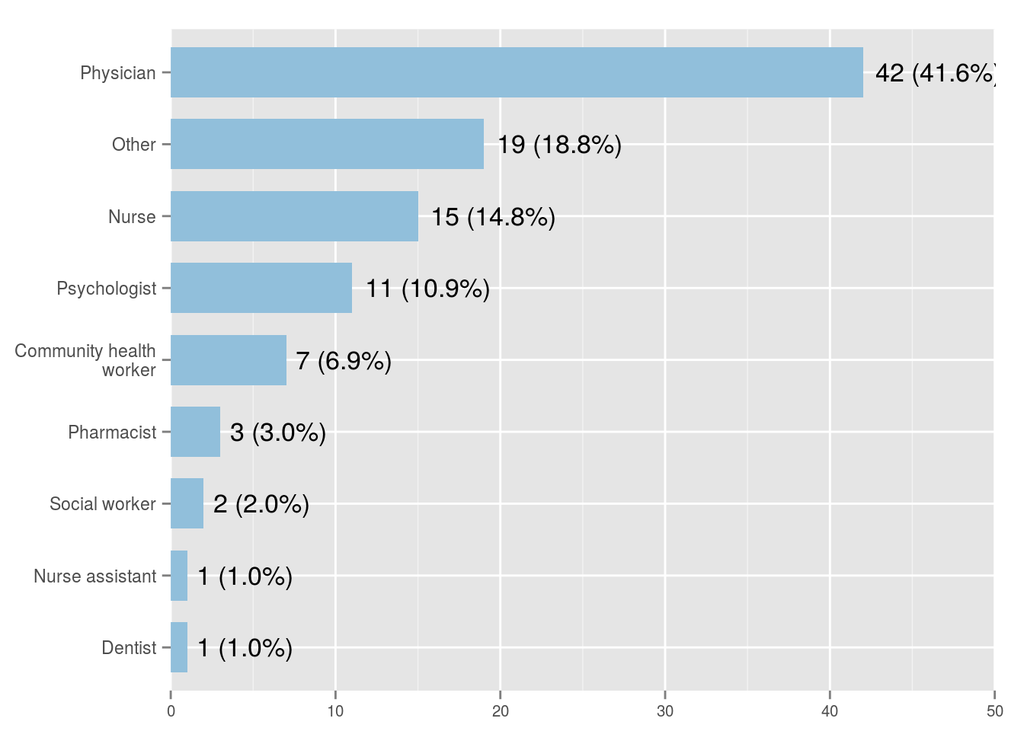

## 6.4 Member of Attud?

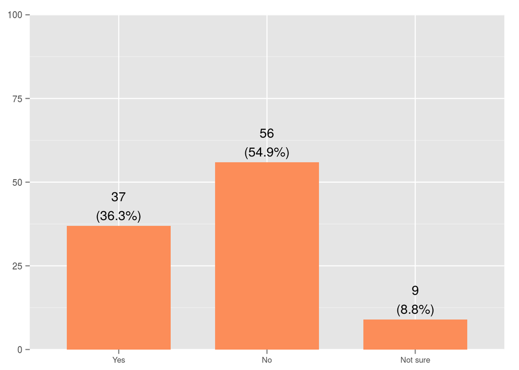

# 7 Access over time

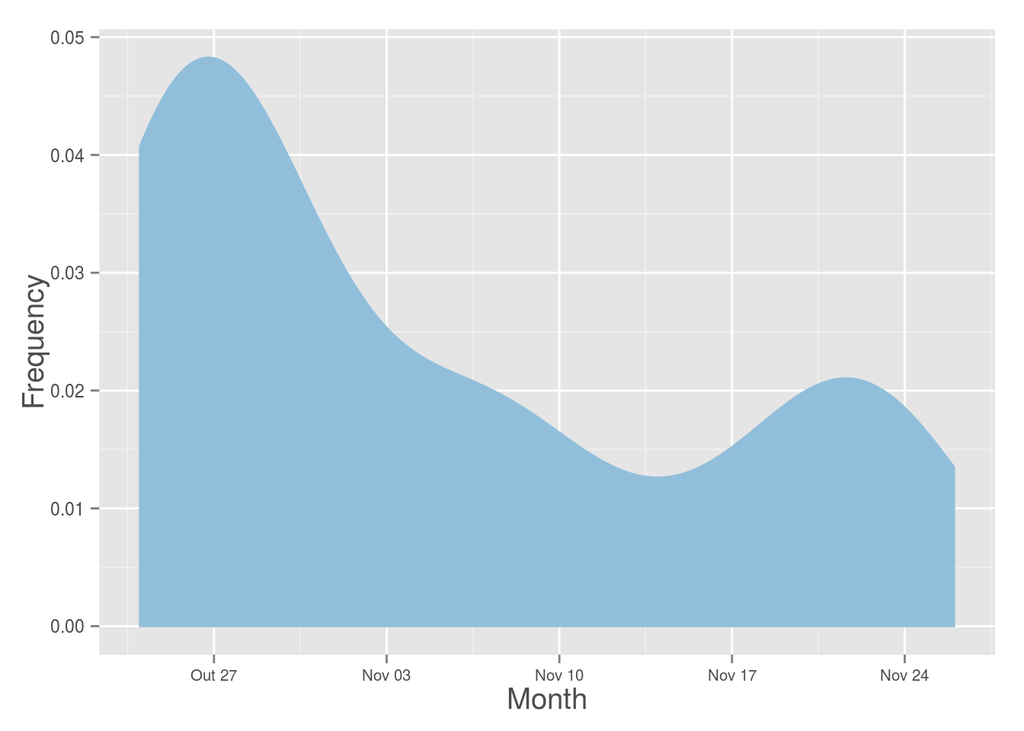